# SC_RNASeq_HW5

Kaushik Raman

# Loading the data

## Step 0: Please install and load the following packages

```r
library(dplyr)
library(Seurat)
library(patchwork)
```

## Step 1: Load the TSV file

```r
GSM3036909 <- read.delim("~/Sem2/Appl_genomics/Homework5 - scRNA-seq attached files Apr 19, 2022 1129 PM/GSM3036909.tsv", sep = "\t")
rownames(GSM3036909) = GSM3036909$Genes
head(GSM3036909,10)
```

[output not shown]

[output cut: 4356 more lines]

[output not shown]

## Step 2: Create a Seurat object.

Call the object pdac1. You set the project argument in the CreateSeuratObject the same. Here we will also request the same criteria as mentioned in the workflow: min.cells=3 and min.features=200.

```r
pdac1 <- CreateSeuratObject(counts = GSM3036909, project = "pdac1", min.cells = 3, min.features = 200)
```

# Quality control

## Step 3: Label the Mitochondrial genes

We don’t want to use cells that have too many mitochondrial genes, so we create a new column to help us summarize how many mitochondrial genes were identified in the different cells.

```r
pdac1[["percent.mt"]] <- PercentageFeatureSet(object = pdac1, pattern = "^MT-")
```

## Step 4: Visualize the distribution

Use the VlnPlot function to view the number of counts, number of features, and the percent mitochondrial genes.

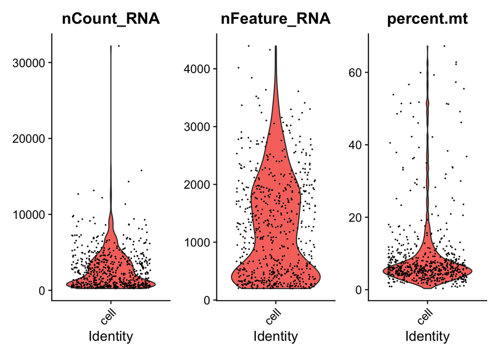

```r
VlnPlot(object = pdac1, features = c("nCount_RNA","nFeature_RNA", "percent.mt"), ncol = 3)
```

## Step 5: Filter data

Only keep the cells that have greater than 200 and less than 2500 unique features and the percent mitochondrial genes is less than 5.

```r
pdac1 <- subset(x = pdac1, subset = nFeature_RNA > 200 & nFeature_RNA < 2500 & percent.mt < 5)
```

# Normalization

## Step 6: Normalize data

Taking the log of the data, makes the data more normal distributed. Normalize data using the LogNormalize method with a scale factor of 10,000

```r
pdac1 <- NormalizeData(object = pdac1, normalization.method = "LogNormalize", scale.factor = 10000)
```

## Step 6: Calculate gene variation

Find the 2000 most variable genes using the FindVariableFeatures command using the vst method

```r
pdac1 <- FindVariableFeatures(object = pdac1, selection.method = "vst", nfeatures = 2000)
```

# PCA

## Step 7: Scale data

Scaling the data normalizes the standard deviation and centers the data. This is an important step before performing PCA.

```r
all.genes <- rownames(x = pdac1)
pdac1 <- ScaleData(object = pdac1, features = all.genes)
```

## Step 8: PCA

Run PCA

```r
pdac1 <- RunPCA(object = pdac1, features = VariableFeatures(object = pdac1))
```

```
## PC_ 1
## Positive:  SPINK1, TM4SF1, DUOXA2, AQP3, APOL1, SOX4, GC, TSPAN8, SLPI, MMP7
##     DMBT1, DSTN, AGR2, SLC2A1, GABRP, ITGA2, EFNA1, AKR1B10, CYB5A, F3
##     CES1, TFF3, AKR1C3, ANKRD36C, MPZL2, FXYD3, FHL2, BAIAP2L1, EIF4A2, LIPH
## Negative:  LAPTM5, TYROBP, ALOX5AP, FPR1, S100A9, BASP1, RGS2, S100A8, SLC2A3, LCP1
##     HCLS1, BCL2A1, FCGR3A, CSF3R, G0S2, FCGR3B, ARRB2, ST20, CD53, C5AR1
##     ARHGDIB, FCGR2A, ITGB2, OSM, FCER1G, SAMSN1, TNFRSF1B, AIF1, SLA, CD37
## PC_ 2
## Positive:  G0S2, CXCL8, CXCR2, S100A8, ST20, BCL2A1, S100A9, HCAR3, FFAR2, IL1R2
##     HCAR2, CMTM2, CSF3R, PROK2, FPR2, MMP9, SOD2, RIPOR2, FPR1, TLR4
##     CXCR1, MME, PLEK, ALPL, FAM177B, RHOH, MGAM, MMP25, AQP9, ALOX5AP
## Negative:  MS4A7, SLCO2B1, HLA-DQB1, HLA-DPA1, TGFBI, HLA-DQA1, HLA-DRA, CD163, HLA-DQA2, HLA-DRB1
##     HLA-DPB1, HLA-DRB5, LGALS1, C1QC, VIM, HLA-DQB2, NPC2, FCGR1A, C1QB, SDS
##     APOE, GPR183, CTSB, C1QA, CSF1R, CD74, MS4A4A, CPVL, CD4, GPX1
## PC_ 3
## Positive:  AQP3, DUOXA2, GC, TFF3, CES1, DMBT1, HLA-DRB1, AKR1B10, HLA-DRB5, CRP
##     HK2, CRISP3, NR4A1, SPINK1, CD74, CPM, ANKRD36, CTSS, FCGBP, REG1A
##     ANKRD36C, SGK1, F5, CYB5A, TSPAN8, AKR1C3, ANKRD36B, AGR2, CA12, ALDOB
## Negative:  COL6A1, SERPINB5, COL6A2, COL17A1, MIA, MGP, CRABP2, SNCG, WNT11, PLAU
##     TIMP3, IGFBP2, S100P, DCBLD2, PCDH7, HMGA2, PODXL, LY6D, FSTL1, HIST1H2BD
##     VCAM1, TOMM70, TRIM29, RNASE1, DMKN, LYPD3, KRT16, PRODH, ZSCAN9, MUC16
## PC_ 4
## Positive:  CD2, SEPT6, CCL5, SPOCK2, IL2RB, CD3D, CD8A, CD7, CD8B, KLRC1
##     GZMB, RGS1, KLRC2, CD247, NPIPA7, IRF4, NPIPA3, NPIPA8, NPIPA2, SLAMF7
##     PRF1, FYN, CXCR3, RPL3, ZNF683, SIT1, TRAF3, LCK, CTLA4, NPIPA1
## Negative:  S100A8, S100A9, PLAUR, SOD2, BCL2A1, FPR1, BASP1, ST20, IL1RN, FCN1
##     SLC11A1, FCGR3B, AQP9, S100P, C5AR1, FCGR3A, SLC2A3, G0S2, S100A12, CSF3R
##     PTGS2, MMP9, CXCL8, FAM177B, EMP1, RAB31, FFAR2, FCGR2A, SMAP2, GCA
## PC_ 5
## Positive:  ATP8A1, PALM, SLCO2A1, FGF2, REEP4, COL4A2, RBM43, RAD51D, ACE, HEG1
##     RASIP1, CYP1B1, SPARC, PCDH17, IGF2, PLEKHG1, SLC4A7, HTRA1, TCF4, AQP1
##     PTPRG, ZNF419, EFEMP1, MKL2, SLFN11, PODXL, ADGRL1, TTC27, ERMARD, FN1
## Negative:  MSX2, MKI67, LPXN, ADCY7, TOP2A, RNF214, NUSAP1, SNAI2, UBE2C, CCNA2
##     CGRRF1, KIF14, CXCL14, MIS18BP1, CEP55, NCAPD2, NEURL1B, RACGAP1, CAD, RFWD3
##     HMMR, PRODH, UBE2T, UBFD1, NPIPA1, DIAPH3, NGEF, LGALS1, NPIPA3, MCM7
```

## Step 9: Visualize data using VizDimLoadings and DimPlot functions. Can you tell from the PCA analyis, the number of cell types that are present?

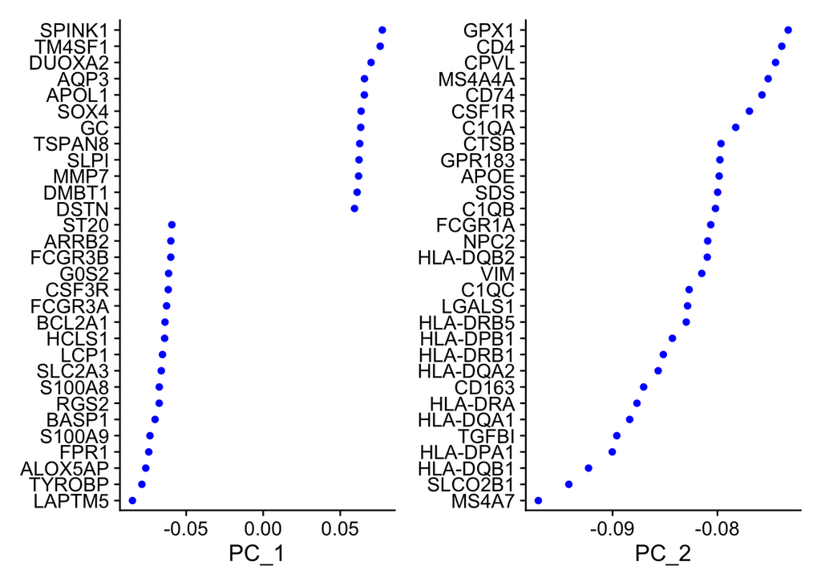

```r
VizDimLoadings(object = pdac1, dims = 1:2, reduction = "pca")
```

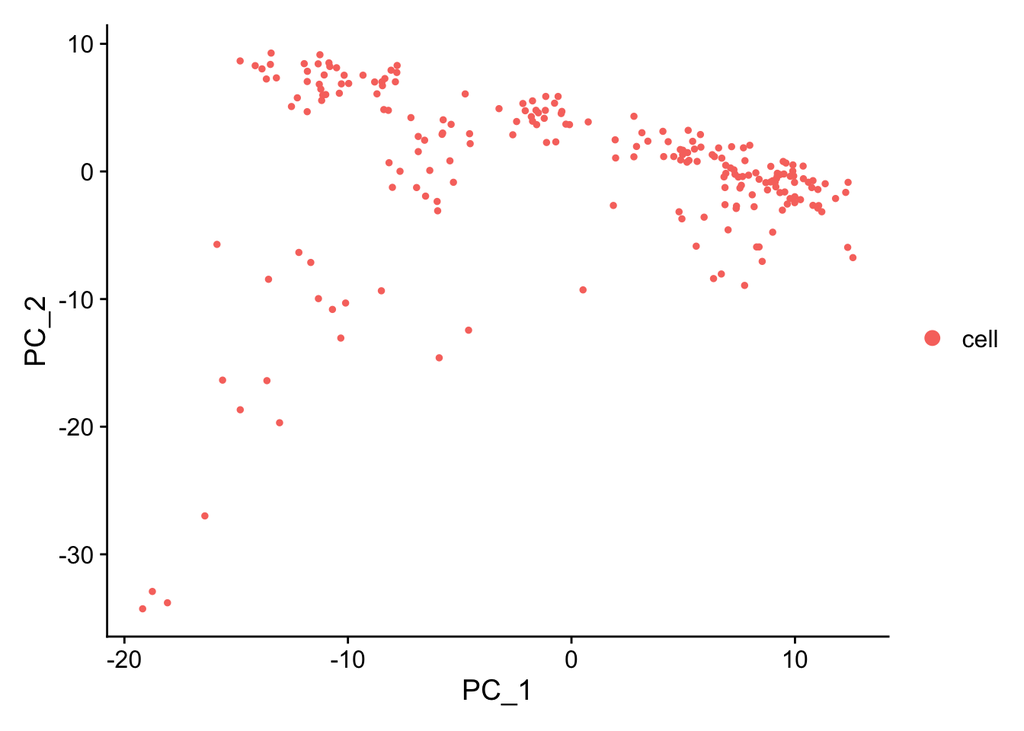

```r
DimPlot(object = pdac1, reduction = "pca")
```

From the PCA, it is not possible to figure out how many cell types are present in this data.

## Step 10: PCA heatmaps

Another way to visualize the variation explained by the PC is creating heatmaps. Create heatmaps of the first 10 dimensions and include 200 cells.

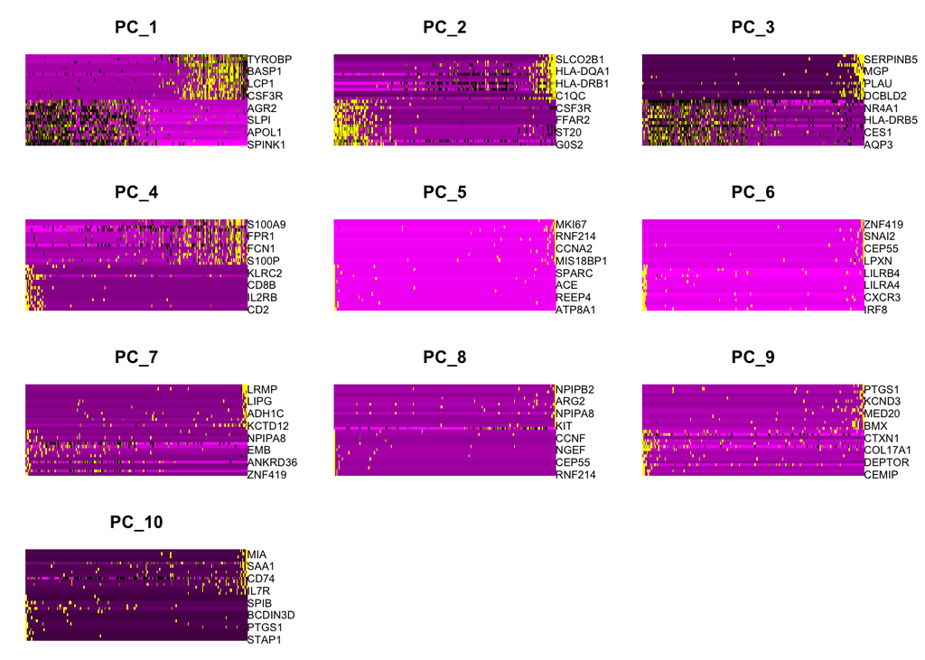

```r
DimHeatmap(object = pdac1, dims = 1:10, cells = 200, balanced = TRUE)
```

## Step 11: Dimensionality

To make this more quantitative, let’s see when does the variation reach the lowest amount of variation explained. Use the JackStraw method with 100 replicates and score the first 20 dimensions.

```r
pdac1 <- JackStraw(object = pdac1, num.replicate = 100)
pdac1 <- ScoreJackStraw(object = pdac1, dims = 1:20)
```

Plot the results for the first 20 dimensions.

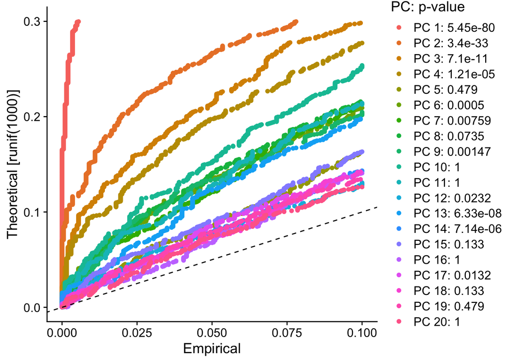

```r
JackStrawPlot(object = pdac1, dims = 1:20)
```

Use the elbow plot

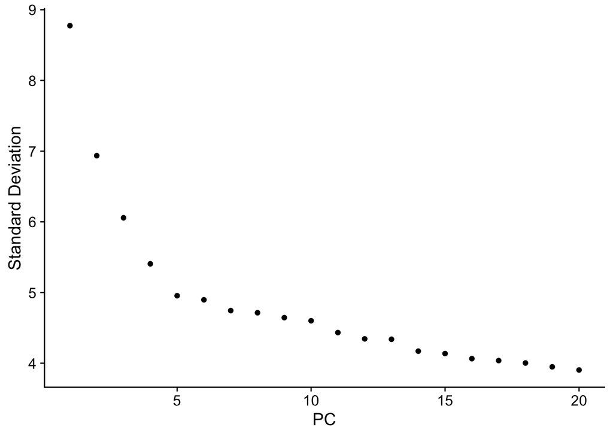

```r
ElbowPlot(object = pdac1)
```

## Step 12: Clustering.

Now we will group together the cells based on where they are located in the different dimensions. Use the FindNeighbors function using the first 9 dimensions.

And then identify the clusters using the FindClusters function.

```r
pdac1 <- FindNeighbors(object = pdac1, dims = 1:9)
pdac1 <- FindClusters(object = pdac1, resolution = 0.5)
```

```
## Modularity Optimizer version 1.3.0 by Ludo Waltman and Nees Jan van Eck
##
## Number of nodes: 212
## Number of edges: 5475
##
## Running Louvain algorithm...
## Maximum modularity in 10 random starts: 0.7875
## Number of communities: 4
## Elapsed time: 0 seconds
```

```r
head(x = Idents(object = pdac1), 10)
```

```
## cell_091.133 cell_143.259 cell_057.153 cell_169.242 cell_058.010 cell_189.209
##            1            1            0            0            3            0
## cell_023.156 cell_018.217 cell_312.307 cell_318.085
##            0            0            0            3
## Levels: 0 1 2 3
```

# tsne/umap

## Step 13: Perform a UMAP analysis using the first 9 dimensions using RunUMAP and then visualize it using DimPlot.

```r
pdac1 <- RunUMAP(object = pdac1, dims = 1:9)
```

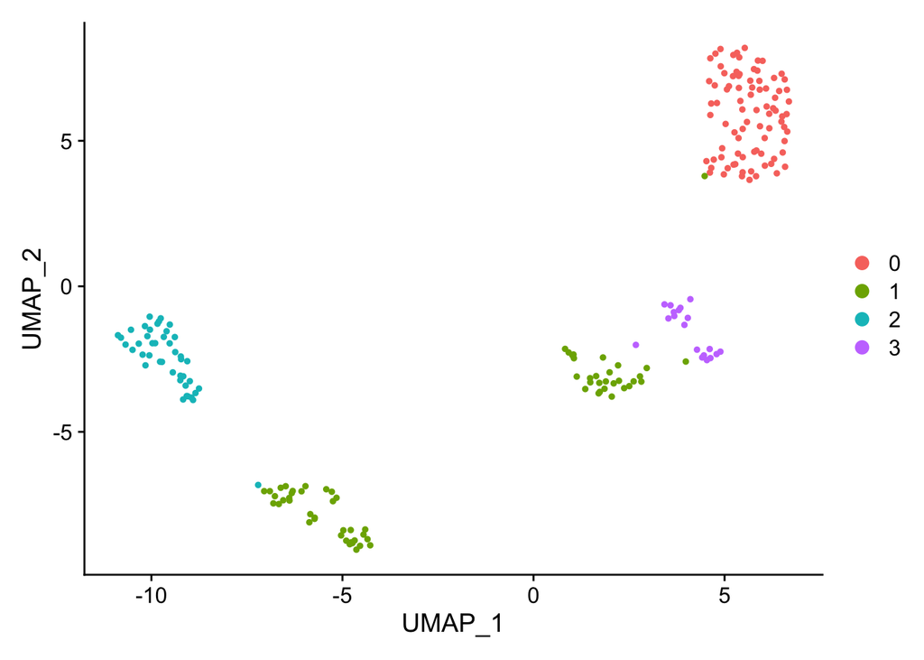

```r
DimPlot(object = pdac1, reduction = "umap")
```

### How many clusters do you get? How many possible mistakes do you see?

From the UMAP, we can see 4 clusters and 4 points that are mistakes as in they are part of another group from their own.

# Step 14: Identify the markers that compare each cluster against all.

Report only positively markers. Use the FindAllMarkers for this.

```r
pdac1.markers <- FindAllMarkers(object = pdac1, only.pos = TRUE, min.pct = 0.25, logfc.threshold = 0.25)
pdac1.markers %>%
    group_by(cluster) %>%
    slice_max(n = 2, order_by = avg_log2FC)
```

```
## # A tibble: 8 × 7
## # Groups:   cluster [4]
##      p_val avg_log2FC pct.1 pct.2 p_val_adj cluster gene
##      <dbl>      <dbl> <dbl> <dbl>     <dbl> <fct>   <chr>
## 1 1.26e-30       3.83 0.882 0.094  1.67e-26 0       SPP1
## 2 4.66e-35       3.29 0.988 0.165  6.18e-31 0       TM4SF4
## 3 1.05e-11       3.00 0.369 0.027  1.40e- 7 1       RGS1
## 4 4.71e- 6       2.93 0.338 0.109  6.24e- 2 1       HLA-DPB1
## 5 1.97e-29       5.86 0.744 0.03   2.61e-25 2       G0S2
## 6 8.26e-17       5.08 0.837 0.367  1.09e-12 2       CXCL8
## 7 2.63e-15       4.86 0.368 0.005  3.49e-11 3       MGP
## 8 3.36e- 9       2.78 0.842 0.306  4.45e- 5 3       KRT17
```

## Step 15: Create a violin plot using one feature from each cluster.

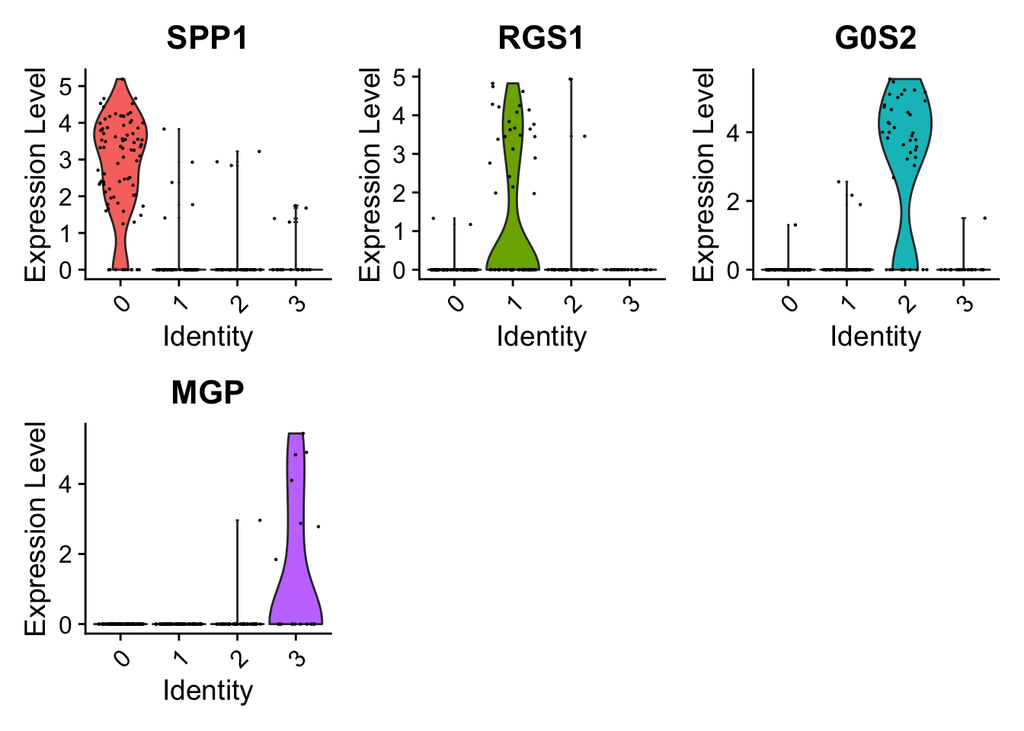

```r
VlnPlot(object = pdac1, features = c("SPP1", "RGS1","G0S2","MGP"))
```

## Step 16: Create a feature plot using the same features as before.

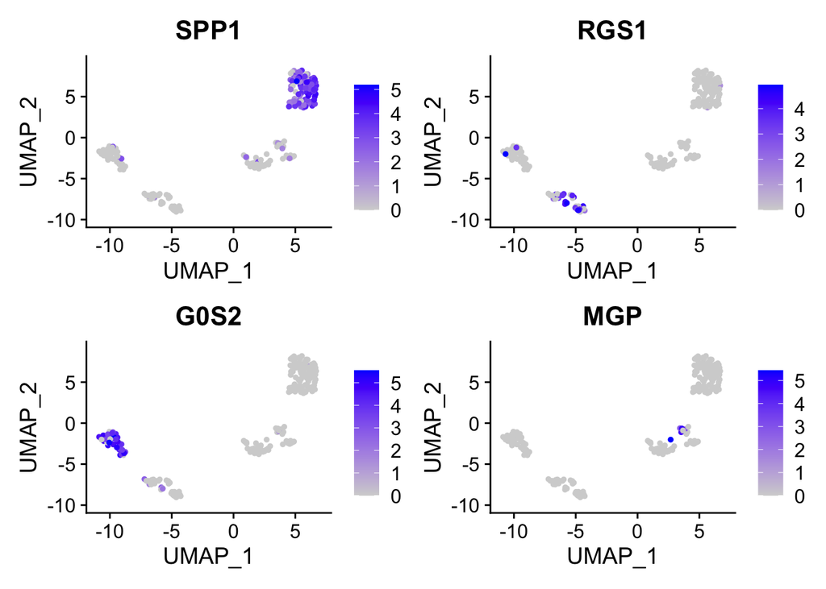

```r
FeaturePlot(object = pdac1, features = c("SPP1", "RGS1","G0S2","MGP"))
```